# Homework 4

Caden Zonnefeld

03 April 2020

## Questions

### Question 1

The boxplot display of GDP by continents indicates the first and third quartiles (by extension the IQR) by the top and bottom of the box and the median (2nd quartile) by the bold line in the middle. Likewise it shows maximum and minimum points by the most extreme points as well as dots which identify any points that are outliers. Comparing box plots can indicate whether variables are generally similar or different. For example in the GDP by continents box plot there is no overlap of the box between Africa and Oceania; thus we can generally conclude that the GDP per capita is different for African and Oceania. Features of this boxplot include (but are not limited to): Asia has many high outliers, Europe has the largest IQR, Africa has the smallest IQR, Asia’s dat is skewed as the space between the 1st and 2nd quartile is much smaller than that between the 2nd and 3rd quartile, there are no lower outliers, and lastly Oceania has the highest median.

### Question 2

Bar plots give a stronger visual since the column/row is filled in all the way up to the data point. Furthermore, when there a frewer groups to compare bar plots are more clear.

### Question 3

A stripplot shows all data points in a line without the outlier identification or box and median that indicate the 1st, 2nd, and 3rd quartiles that boxplots offer. A strip plot allows you to see the density of data points and a more meaningful understanding of any potential skewness in the data.

### Question 4

Scatterplots are particularly useful to identify the linearity of data, equal variance of points at any place on the X axis, and normal distribution of data points about each point on the X axis. Each of these can be observed by viewing a scatterplot. For example the scatterplot that uses Life Expectancy and GDP Per Capita does not have equal variance since the variance of data points increases as Life Expectancy increases.

## Graphing Time

### Question 7

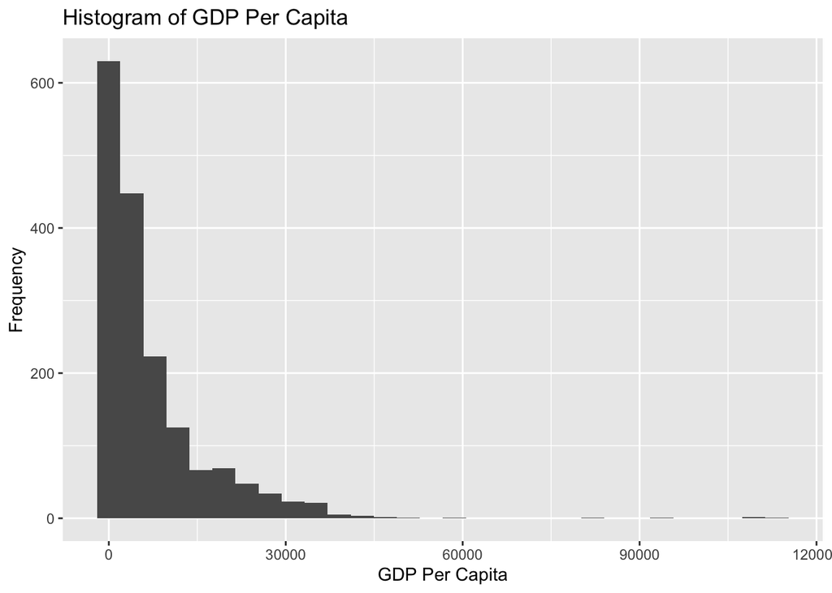

```r
library(gapminder)
library(ggplot2)

ggplot(gapminder, aes(x=gdpPercap))+geom_histogram()+labs(title="Histogram of GDP Per Capita")+xlab("GDP Per Capita")+ylab("Frequency")
```

### Question 8

Recreated boxplot using base r graphics.

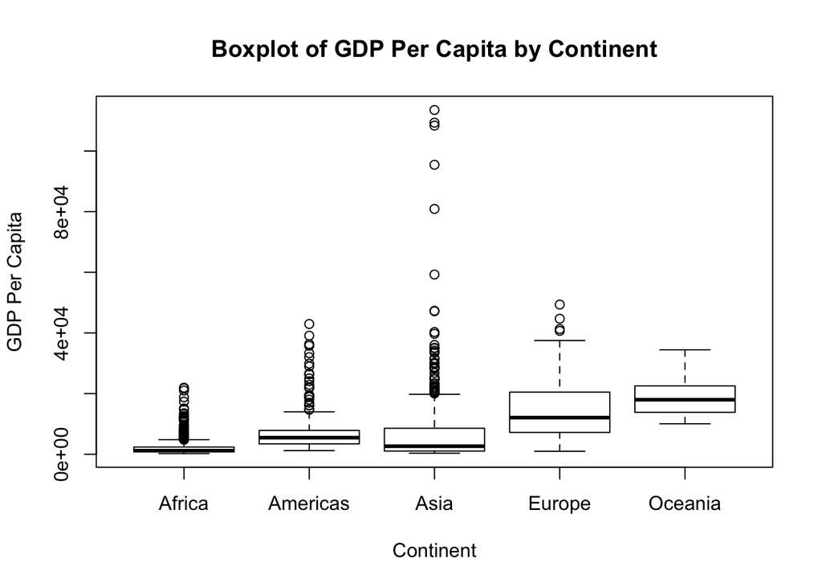

```r
boxplot(gapminder$gdpPercap~gapminder$continent, main="Boxplot of GDP Per Capita by Continent", xlab = "Continent", ylab = "GDP Per Capita")
```

Recreated bar chart using base r graphics.

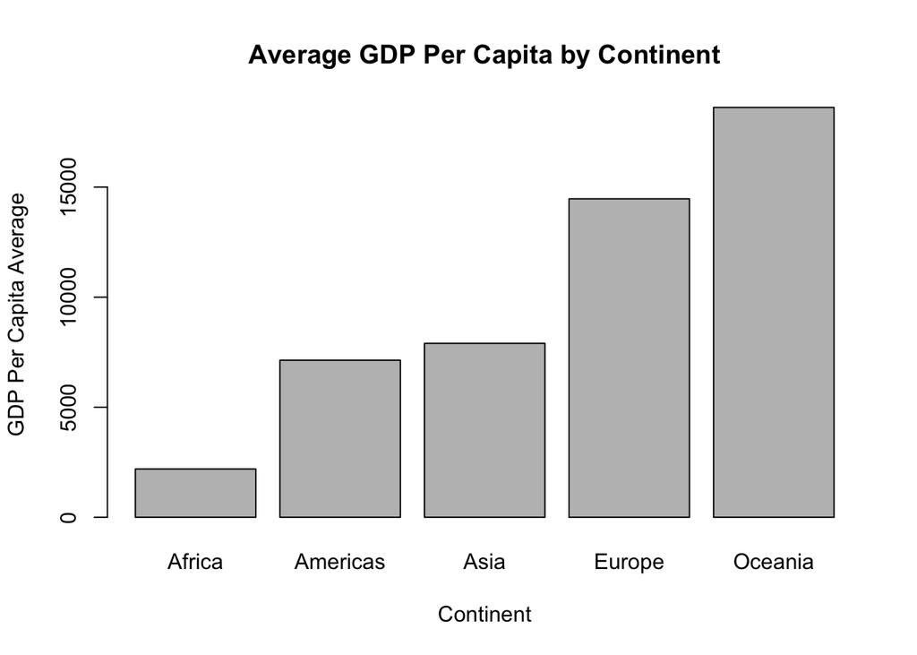

```r
gap <- aggregate(gdpPercap ~ continent, gapminder, mean)
names(gap)[2] <- "gdpPercapAverage"
barplot(gap$gdpPercapAverage, main="Average GDP Per Capita by Continent", ylab="GDP Per Capita Average", xlab = "Continent", names.arg=gap$continent)
```

Recreated dot plot using base r graphics.

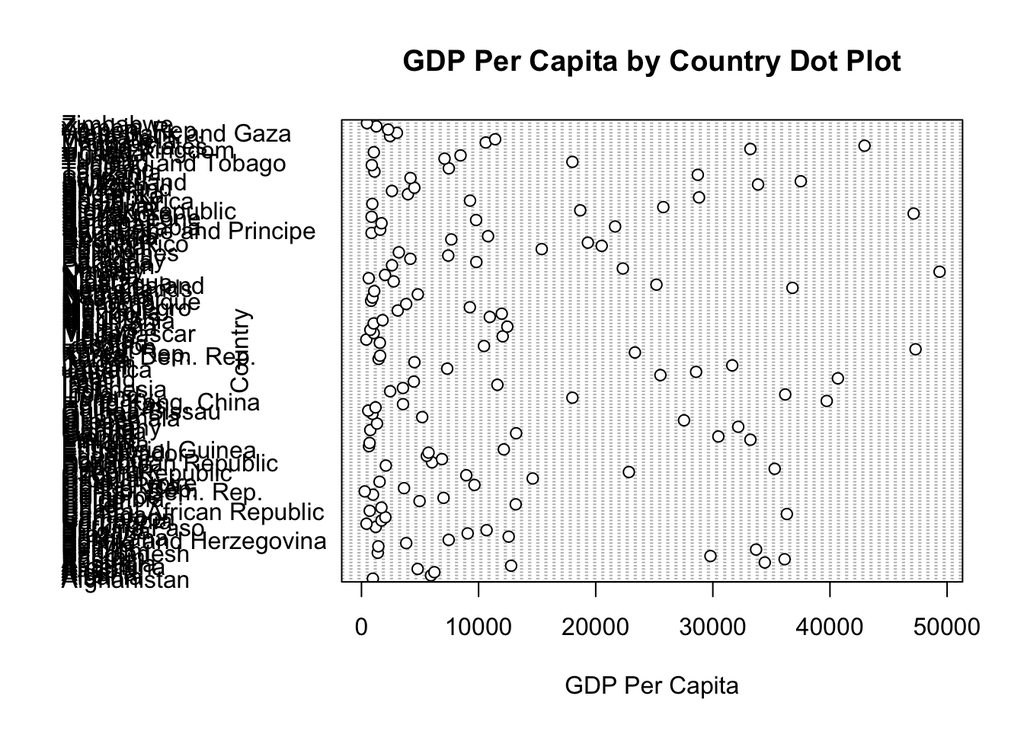

```r
gap90 <- gapminder[gapminder$year==2007,]
dotchart(gap90$gdpPercap,gap90$country, main = "GDP Per Capita by Country Dot Plot", ylab = "Country",xlab = "GDP Per Capita")
```

Recreated the ordered dot plot using base r graphics.

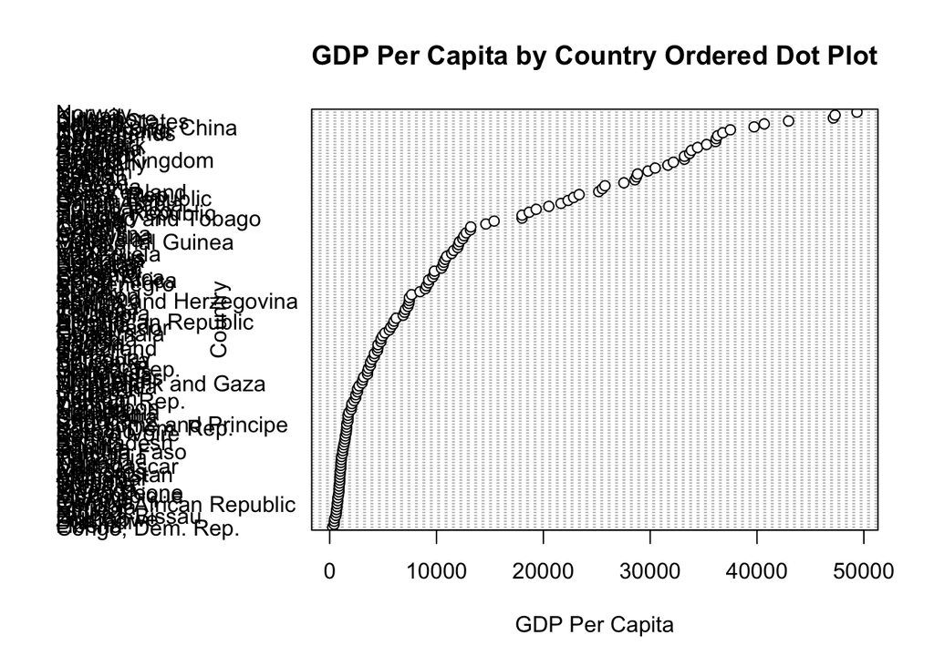

```r
gap90ordered <- gap90[order(gap90$gdpPercap),]
dotchart(gap90ordered$gdpPercap,gap90ordered$country, main = "GDP Per Capita by Country Ordered Dot Plot", ylab = "Country", xlab = "GDP Per Capita")
```

Recreated strip plot using base r graphics.

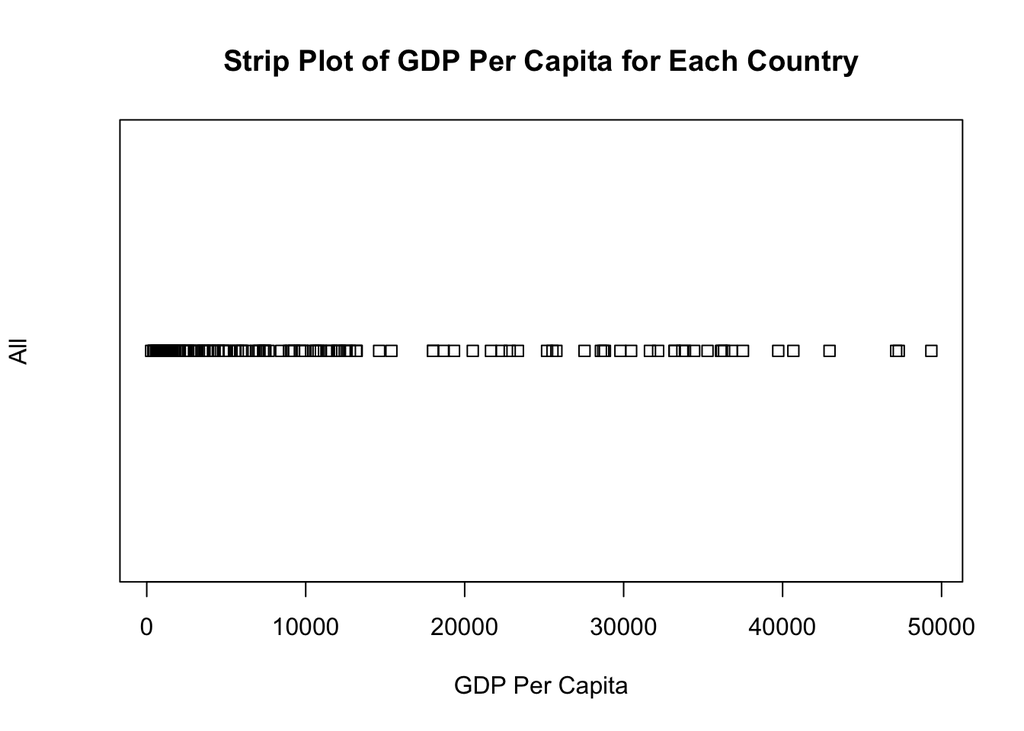

```r
stripchart(gap90$gdpPercap, main="Strip Plot of GDP Per Capita for Each Country",ylab="All", xlab = "GDP Per Capita")
```

Recreated the first scatterplot using base r graphics.

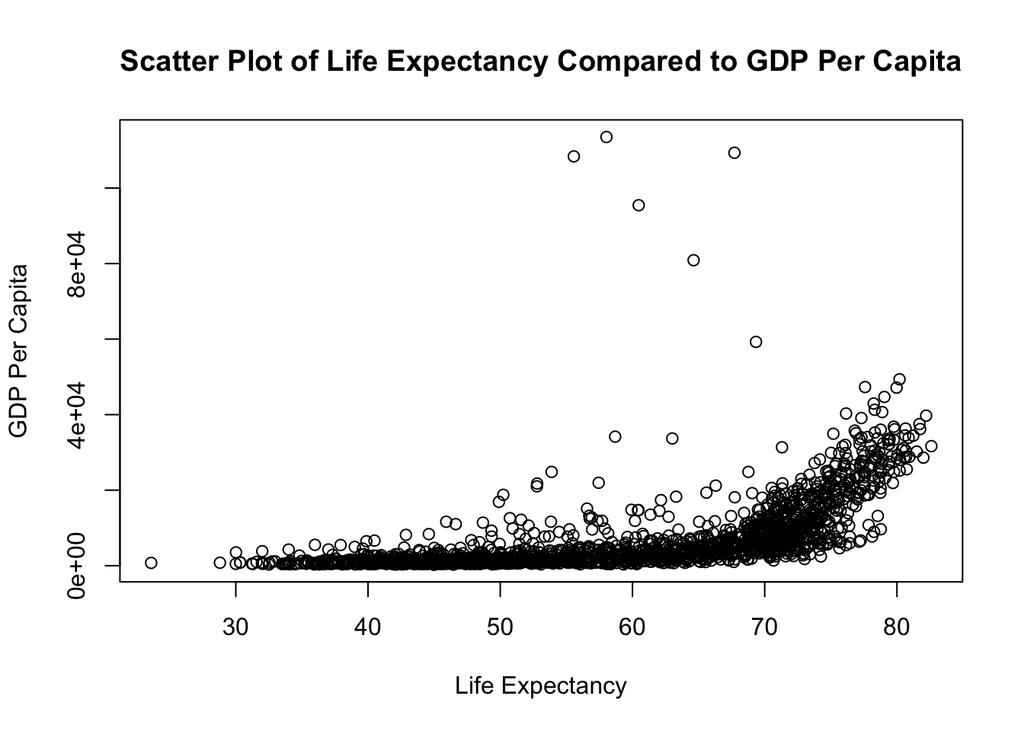

```r
plot(gapminder$lifeExp,gapminder$gdpPercap, main = "Scatter Plot of Life Expectancy Compared to GDP Per Capita", ylab = "GDP Per Capita", xlab = "Life Expectancy")
```

Recreated the second scatterplot using base r graphics.

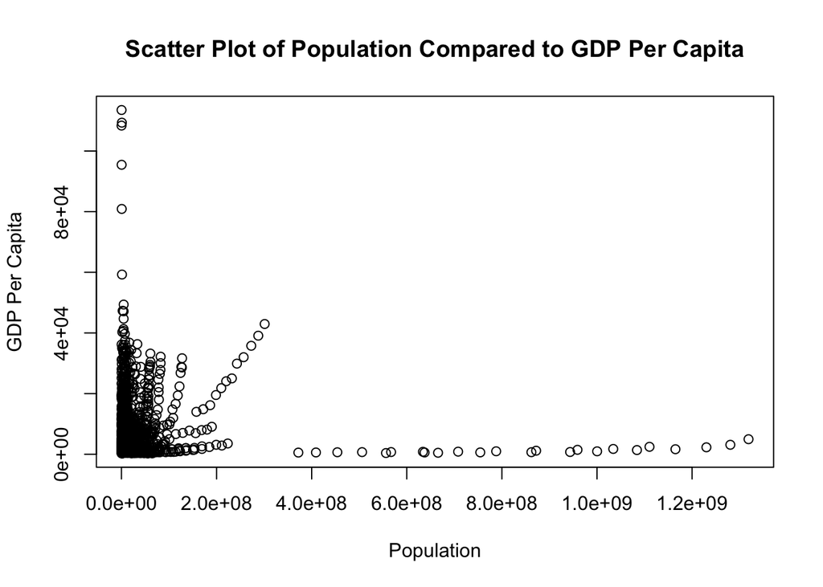

```r
plot(gapminder$pop,gapminder$gdpPercap, main = "Scatter Plot of Population Compared to GDP Per Capita", ylab = "GDP Per Capita", xlab = "Population")
```

### Question 9

First graph of interest:

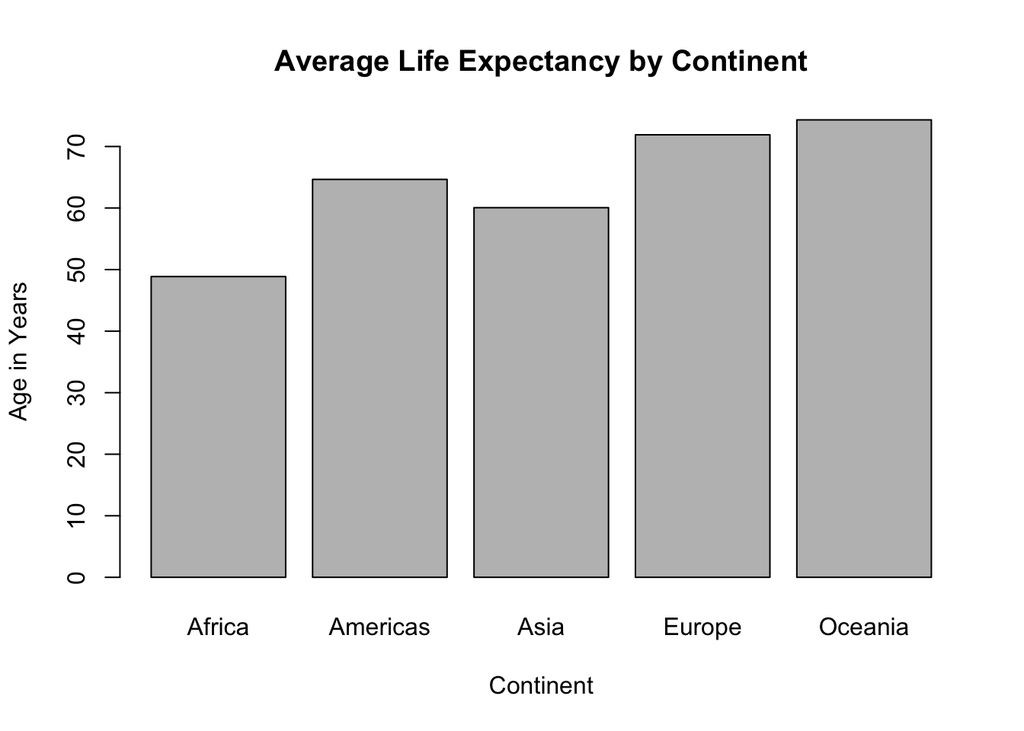

```r
gap2 <- aggregate(lifeExp~continent,gapminder,mean)
names(gap2)[2] <- "AverageLifeExp"
barplot(gap2$AverageLifeExp, names.arg=gap2$continent, main = "Average Life Expectancy by Continent", ylab = "Age in Years", xlab = "Continent")
```

I used base graphics to make a bar chart of the average life expectancy for each continent. The bar chart reveals that Oceania has the highest average life expectancy followed by Europe, the Americas, Asia, and lastly Africa. Furthermore, we can see that Europe and Oceania are the only continents with average life expectancies greather than 70.

Second graph of interest:

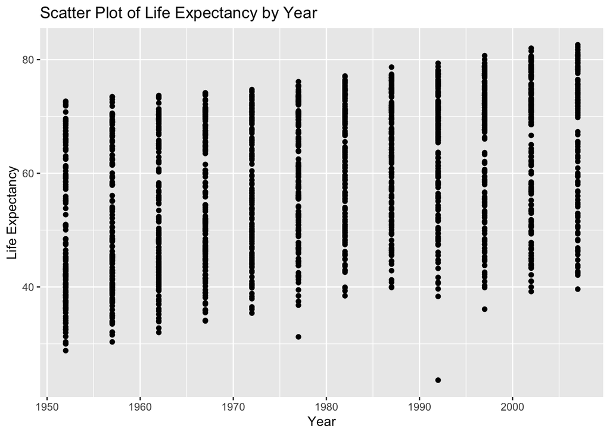

```r
ggplot(gapminder, aes(x=year,y=lifeExp))+geom_point()+labs(title="Scatter Plot of Life Expectancy by Year")+ylab("Life Expectancy")+xlab("Year")
```

I used ggplot2 to create a graph that compared life expectancy to year. I hypothesized that life expectancy would increase with time as better medical technology is developed. The data agrees with my hypothesis as there is a general trend of life expectancy increasing as the years go on. The data also reveals that there is an outlier of low life expectancy that was collected in ~1992, this could be the result of a natural disaster or catastrophe. The reason that the data is in discrete chunks for this scatter plot is because thae data is collected once every five years; that is why this scatter plot does not take on the continous nature that we have seen in other examples.